# Season report: LoneWolf Season 16

[figure not shown]

### Overview

[figure not shown]

1st place

[wookash_888](https://www.lichess4545.com/lonewolf/season/16/player/wookash_888/)

2nd place

[Anjablaserr](https://www.lichess4545.com/lonewolf/season/16/player/Anjablaserr/)

3rd place

[TheDrunkenLawyer](https://www.lichess4545.com/lonewolf/season/16/player/TheDrunkenLawyer/)

#### Story of the season

[figure not shown]

### Game times / durations

#### When were games played?

[figure not shown]

#### How long did games take?

[figure not shown]

#### Longest games (moves)

*Includes games ranked at or above the 90th percentile by number of moves.*

| Rank | Players / Link | Date | Moves |
| --- | --- | --- | --- |
| 1 | leobkho - Thundercougarfalcon | Fri 8 Nov 2019 | 117 |
| 2 | OneKindKing - jessehf | Thu 21 Nov 2019 | 115 |
| 3 | sivvaaa - Notyetuhuru | Fri 22 Nov 2019 | 86 |
| 4 | sivvaaa - k-night-moves | Wed 15 Jan 2020 | 79 |
| 5 | Pawndercover - ChessinBlackandWhite | Tue 7 Jan 2020 | 78 |
| 5 | OneKindKing - rampichino | Mon 11 Nov 2019 | 78 |
| 6 | Anjablaserr - wookash_888 | Sun 12 Jan 2020 | 75 |
| 7 | kostasvl - Notyetuhuru | Tue 24 Dec 2019 | 74 |
| 7 | Whizzz - Bole1981 | Sat 21 Dec 2019 | 74 |
| 7 | ashtangachess - isuckatchess247 | Tue 5 Nov 2019 | 74 |

[output cut: 23 more lines]

#### Longest games

*Includes games ranked at or above the 90th percentile by total clock time.*[^3]

| Rank | Players / Link | Date | Total time |
| --- | --- | --- | --- |
| 1 | OneKindKing - jessehf | Thu 21 Nov 2019 | 2h 18m 40s |
| 2 | OneKindKing - rampichino | Mon 11 Nov 2019 | 2h 8m 43s |
| 3 | Anjablaserr - wookash_888 | Sun 12 Jan 2020 | 2h 6m 53s |
| 4 | sivvaaa - k-night-moves | Wed 15 Jan 2020 | 2h 5m 50s |
| 5 | Whizzz - Bole1981 | Sat 21 Dec 2019 | 2h 5m 36s |
| 6 | chesseric44 - jessehf | Fri 8 Nov 2019 | 2h 3m 33s |
| 7 | RandomJSDev - MrKamikazeBoy | Fri 8 Nov 2019 | 1h 54m 5s |
| 8 | Sesquipedalism - fritsj | Sun 8 Dec 2019 | 1h 53m 8s |
| 9 | Bole1981 - rodeo | Wed 27 Nov 2019 | 1h 52m 49s |
| 10 | therealseedling - toni4127 | Sun 1 Dec 2019 | 1h 51m 59s |

[output cut: 23 more lines]

### By board / rating band

#### ACPL / blunder rate

[figure not shown]

#### Games with lowest combined ACPL

The games with the lowest combined ACPL (including draws).

| Players / Link | Result | Sum ACPL | Date |
| --- | --- | --- | --- |
| TheDrunkenLawyer - StrategosAutokrator | 1/2-1/2 | 14 | Tue 12 Nov 2019 |
| wookash_888 - floum | 1/2-1/2 | 18 | Mon 16 Dec 2019 |
| TheDrunkenLawyer - wookash_888 | 1/2-1/2 | 19 | Mon 27 Jan 2020 |
| leobkho - Thundercougarfalcon | 0-1 | 20 | Fri 8 Nov 2019 |
| rezoons - SycoraxCirce | 1/2-1/2 | 21 | Sat 25 Jan 2020 |
| yago666 - alms | 1/2-1/2 | 22 | Sat 7 Dec 2019 |
| manbitesdog - TheDrunkenLawyer | 1/2-1/2 | 23 | Sun 10 Nov 2019 |
| GGrkinic - superbohemio | 1-0 | 24 | Wed 22 Jan 2020 |
| Pedropablo72 - rampichino | 1/2-1/2 | 24 | Wed 15 Jan 2020 |
| Fianchettoed - Bole1981 | 0-1 | 26 | Sun 12 Jan 2020 |

#### Excl. draws

The *decisive* games with the lowest combined ACPL.

| Players / Link | Result | Sum ACPL | Date |
| --- | --- | --- | --- |
| leobkho - Thundercougarfalcon | 0-1 | 20 | Fri 8 Nov 2019 |
| GGrkinic - superbohemio | 1-0 | 24 | Wed 22 Jan 2020 |
| Fianchettoed - Bole1981 | 0-1 | 26 | Sun 12 Jan 2020 |
| rederik79 - sivvaaa | 0-1 | 27 | Sun 12 Jan 2020 |
| bigott - RandomJSDev | 1-0 | 31 | Fri 15 Nov 2019 |
| Queen_Blunder - wookash_888 | 0-1 | 34 | Thu 7 Nov 2019 |
| WildGooseChess - ashtangachess | 0-1 | 35 | Tue 3 Dec 2019 |
| CamLeslie - superbohemio | 0-1 | 38 | Sat 21 Dec 2019 |
| flaxl - jmvanaclocha | 0-1 | 38 | Sun 8 Dec 2019 |
| Pawndercover - Golodion | 1-0 | 39 | Wed 1 Jan 2020 |

[output cut: 1 more lines]

### Openings - tables

#### Popular openings

All openings played in the season, excluding variations.

| Rank | Opening | Games | White % | 1-0 % | Draw % | 0-1 % | Mean Eval | Avg Rating |
| --- | --- | --- | --- | --- | --- | --- | --- | --- |
| 1 | Sicilian Defense | 67 | 51.4925373134328 | 44.7761194029851 | 13.4328358208955 | 41.7910447761194 | 0.26734375 | 1914.32089552239 |
| 2 | English Opening | 23 | 43.4782608695652 | 39.1304347826087 | 8.69565217391304 | 52.1739130434783 | 0.659090909090909 | 1944.78260869565 |
| 3 | French Defense | 21 | 59.5238095238095 | 57.1428571428571 | 4.76190476190476 | 38.0952380952381 | 1.365 | 1943.80952380952 |
| 4 | Caro-Kann Defense | 20 | 60 | 55 | 10 | 35 | 1.02 | 1924.9 |
| 5 | Queen's Gambit Declined | 19 | 60.5263157894737 | 47.3684210526316 | 26.3157894736842 | 26.3157894736842 | 0.896842105263158 | 2022.86842105263 |
| 6 | Slav Defense | 17 | 52.9411764705882 | 35.2941176470588 | 35.2941176470588 | 29.4117647058824 | 1.03823529411765 | 2048.94117647059 |
| 7 | Nimzo-Indian Defense | 14 | 57.1428571428571 | 57.1428571428571 | 0 | 42.8571428571429 | 0.779166666666667 | 1987.57142857143 |
| 7 | Queen's Pawn Game | 14 | 50 | 42.8571428571429 | 14.2857142857143 | 42.8571428571429 | 0.480769230769231 | 1869.92857142857 |
| 8 | Pirc Defense | 10 | 55 | 50 | 10 | 40 | -0.77 | 1957 |
| 8 | Ruy Lopez | 10 | 40 | 30 | 20 | 50 | 0.027 | 2009.35 |

[output cut: 44 more lines]

#### Popular variations

All openings played in the season, including variations.

| Rank | Opening | Games | White % | 1-0 % | Draw % | 0-1 % | Mean Eval | Avg Rating |
| --- | --- | --- | --- | --- | --- | --- | --- | --- |
| 1 | Nimzo-Indian Defense: Classical Variation | 8 | 75 | 75 | 0 | 25 | 0.025 | 1955.6875 |
| 2 | Trompowsky Attack | 7 | 57.1428571428571 | 42.8571428571429 | 28.5714285714286 | 28.5714285714286 | 0.335 | 1948.42857142857 |
| 3 | Four Knights Game: Scotch Variation Accepted | 6 | 41.6666666666667 | 16.6666666666667 | 50 | 33.3333333333333 | 0.656 | 2110.5 |
| 3 | French Defense: Exchange Variation | 6 | 33.3333333333333 | 33.3333333333333 | 0 | 66.6666666666667 | 0.171666666666667 | 1968.16666666667 |
| 4 | Alekhine Defense: Modern Variation, Main Line | 5 | 50 | 40 | 20 | 40 | -0.065 | 1970.5 |
| 4 | Caro-Kann Defense: Exchange Variation | 5 | 50 | 40 | 20 | 40 | 0.495 | 1929.7 |
| 4 | English Opening: Anglo-Indian Defense | 5 | 20 | 20 | 0 | 80 | -0.56 | 1917.1 |
| 4 | Sicilian Defense: Najdorf Variation, English Attack | 5 | 60 | 60 | 0 | 40 | 0.46 | 1891.5 |
| 5 | Englund Gambit Complex: Hartlaub-Charlick Gambit | 4 | 50 | 50 | 0 | 50 | 0.54 | 2088.25 |
| 5 | Queen's Gambit Declined: Exchange Variation, Positional Variation | 4 | 50 | 25 | 50 | 25 | 0.495 | 2029.875 |

[output cut: 235 more lines]

#### Best for White

The best-scoring main openings for White.

*Includes all main openings played in at least 10 games.*

| Rank | Opening | Games | White's score (%) | White wins (%) | Draws (%) | Black wins (%) | Mean eval after 15 moves | Avg rating |
| --- | --- | --- | --- | --- | --- | --- | --- | --- |
| 1 | Queen's Gambit Declined | 19 | 60.5263157894737 | 47.3684210526316 | 26.3157894736842 | 26.3157894736842 | 0.896842105263158 | 2022.86842105263 |
| 2 | Caro-Kann Defense | 20 | 60 | 55 | 10 | 35 | 1.02 | 1924.9 |
| 3 | French Defense | 21 | 59.5238095238095 | 57.1428571428571 | 4.76190476190476 | 38.0952380952381 | 1.365 | 1943.80952380952 |
| 4 | Nimzo-Indian Defense | 14 | 57.1428571428571 | 57.1428571428571 | 0 | 42.8571428571429 | 0.779166666666667 | 1987.57142857143 |
| 5 | Slav Defense | 17 | 52.9411764705882 | 35.2941176470588 | 35.2941176470588 | 29.4117647058824 | 1.03823529411765 | 2048.94117647059 |
| 6 | Sicilian Defense | 67 | 51.4925373134328 | 44.7761194029851 | 13.4328358208955 | 41.7910447761194 | 0.26734375 | 1914.32089552239 |
| 7 | Queen's Pawn Game | 14 | 50 | 42.8571428571429 | 14.2857142857143 | 42.8571428571429 | 0.480769230769231 | 1869.92857142857 |
| 8 | English Opening | 23 | 43.4782608695652 | 39.1304347826087 | 8.69565217391304 | 52.1739130434783 | 0.659090909090909 | 1944.78260869565 |

#### Best for Black

The best-scoring main openings for Black.

*Includes all main openings played in at least 10 games.*

| Rank | Opening | Games | Black's score (%) | Black wins (%) | Draws (%) | White wins (%) | Mean eval after 15 moves | Avg rating |
| --- | --- | --- | --- | --- | --- | --- | --- | --- |
| 1 | English Opening | 23 | 56.5217391304348 | 52.1739130434783 | 8.69565217391304 | 39.1304347826087 | 0.659090909090909 | 1944.78260869565 |
| 2 | Queen's Pawn Game | 14 | 50 | 42.8571428571429 | 14.2857142857143 | 42.8571428571429 | 0.480769230769231 | 1869.92857142857 |
| 3 | Sicilian Defense | 67 | 48.5074626865672 | 41.7910447761194 | 13.4328358208955 | 44.7761194029851 | 0.26734375 | 1914.32089552239 |
| 4 | Slav Defense | 17 | 47.0588235294118 | 29.4117647058824 | 35.2941176470588 | 35.2941176470588 | 1.03823529411765 | 2048.94117647059 |
| 5 | Nimzo-Indian Defense | 14 | 42.8571428571429 | 42.8571428571429 | 0 | 57.1428571428571 | 0.779166666666667 | 1987.57142857143 |
| 6 | French Defense | 21 | 40.4761904761905 | 38.0952380952381 | 4.76190476190476 | 57.1428571428571 | 1.365 | 1943.80952380952 |
| 7 | Caro-Kann Defense | 20 | 40 | 35 | 10 | 55 | 1.02 | 1924.9 |
| 8 | Queen's Gambit Declined | 19 | 39.4736842105263 | 26.3157894736842 | 26.3157894736842 | 47.3684210526316 | 0.896842105263158 | 2022.86842105263 |

#### Popular gambits

All gambit openings played in the season.[^4]

| Rank | Name | Games | White score (%) |
| --- | --- | --- | --- |
| 1 | Benko Gambit | 5 | 50 |
| 2 | Scotch Gambit | 2 | 50 |
| 2 | Smith-Morra Gambit | 2 | 50 |
| 3 | Anti-Moscow Gambit | 2 | 0 |
| 4 | Geller Gambit | 1 | 100 |
| 4 | Stafford Gambit | 1 | 100 |
| 5 | Greco Gambit | 1 | 50 |
| 6 | Blackmar-Diemer Gambit | 1 | 0 |
| 6 | Deutz Gambit | 1 | 0 |

#### Gambiteers

The players who enjoyed the most success when playing gambits.[^5]

*Shows all players who scored at least 50% playing gambits in the season (min. games: 2).*

| Rank | Player | Games | % Score |
| --- | --- | --- | --- |
| 1 | Snodder | 2 | 100 |
| 2 | Bole1981 | 2 | 50 |

### Openings - sunburst

Click on the image below to see a sunburst plot of all openings played in the season.

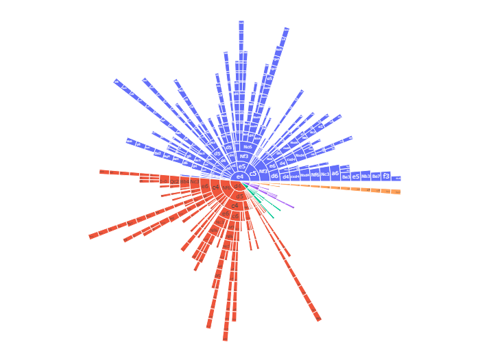

### Awards

Because winning isn’t everything; it’s the only thing :)

See the footnote for further details on selected awards.[^6]

| Award | Description | Winner | Details | Honourable mentions |
| --- | --- | --- | --- | --- |
| x | Archbishop of Accuracy | Thundercougarfalcon | 5 ACPL over 117 moves | ashtangachess, TheDrunkenLawyer |
| x | Bullet Boss | fritsj | 25 moves | Thundercougarfalcon, jessehf |
| x | David Award | Josip_buje | Opponents' record: 28.5/38 | jessehf, Fairespirareletorri |
| x | Gambit Guru | Snodder | 100% from 2 games | NA |
| x | Giri Award | TheDrunkenLawyer | 6 draws |  |
| x | Grischuk's Cousin | Anjablaserr | Had 8m 50s left after 10 moves | Anjablaserr, Anjablaserr |
| x | Houdini Award | fritsj |  | wookash_888, alp_arslan92 |
| x | Intimate with Increment | pepepibote | 34.2% | k-night-moves, Sesquipedalism |
| x | Musing or Snoozing | superbohemio | Spent 25m 56s | kostasvl, kostasvl |
| x | MVP Award | adande1 | +6-3=1 perf 2045, initially 1748 | Sesquipedalism, Snodder |

[output cut: 7 more lines]

### Detailed statistics

All the following tables are sortable and searchable.

#### Best performances / highest accuracy

##### Best relative perfs

Shows players’ *relative* performance ratings: season performance rating minus initial rating.[^7]

*Includes all players with a positive relative performance rating over at least five games.*

| # | Player | Games | W | D | L | Initial | Perf | Diff. |
| --- | --- | --- | --- | --- | --- | --- | --- | --- |
| 1 | adande1 | 10 | 6 | 1 | 3 | 1748 | 2044.9 | 296.9 |
| 2 | Sesquipedalism | 8 | 4 | 2 | 2 | 1900 | 2181.875 | 281.875 |
| 3 | Snodder | 11 | 5 | 3 | 3 | 1847 | 2104.63636363636 | 257.636363636364 |
| 4 | ChessinBlackandWhite | 9 | 6 | 2 | 1 | 2022 | 2268.66666666667 | 246.666666666667 |
| 5 | darubaru | 7 | 3 | 0 | 4 | 1625 | 1867.85714285714 | 242.857142857143 |
| 6 | NoNameK | 6 | 5 | 0 | 1 | 2161 | 2369.83333333333 | 208.833333333333 |
| 7 | Anjablaserr | 9 | 7 | 1 | 1 | 2100 | 2299.77777777778 | 199.777777777778 |
| 8 | wookash_888 | 10 | 7 | 3 | 0 | 2253 | 2438.5 | 185.5 |
| 9 | rodeo | 8 | 4 | 1 | 3 | 1874 | 2049.125 | 175.125 |
| 10 | fismoluni | 10 | 5 | 0 | 5 | 1800 | 1974.4 | 174.4 |

[output cut: 31 more lines]

##### Lowest ACPL

*Includes the 100 players with the lowest ACPL (min. 100 moves played).*

| Rank | Player | Moves | ACPL |
| --- | --- | --- | --- |
| 1 | Thundercougarfalcon | 117 | 5 |
| 2 | ashtangachess | 140 | 13.8 |
| 3 | TheDrunkenLawyer | 439 | 17.7722095671982 |
| 4 | wookash_888 | 397 | 20.5340050377834 |
| 5 | Josip_buje | 188 | 22.6436170212766 |
| 6 | k-night-moves | 110 | 24.7909090909091 |
| 7 | IsaVulpes | 221 | 25.4072398190045 |
| 8 | Pushedpawn | 158 | 25.8417721518987 |
| 9 | alp_arslan92 | 295 | 26.0372881355932 |
| 10 | Fianchettoed | 341 | 29.1876832844575 |

[output cut: 77 more lines]

#### Time spent / strongest opponents

##### Time spent

*Includes the 50 players who spent the most clock time over the season.*

| Rank | Player | Games | Total time spent |
| --- | --- | --- | --- |
| 1 | MrKamikazeBoy | 10 | 8h 34m 22s |
| 2 | Bole1981 | 11 | 8h 12m 18s |
| 3 | Whizzz | 11 | 8h 11m 41s |
| 4 | fritsj | 11 | 7h 54m 25s |
| 5 | Anjablaserr | 10 | 7h 40m 46s |
| 6 | JSlavik | 11 | 7h 25m 56s |
| 7 | Snodder | 11 | 7h 16m 29s |
| 8 | floum | 11 | 7h 7m 48s |
| 9 | wookash_888 | 11 | 6h 44m 12s |
| 10 | rezoons | 11 | 6h 39m 44s |

[output cut: 40 more lines]

##### Time spent per move (after move 10)

*Includes everyone who played at least three games.*

| Rank | Player | Games | Moves | Time spent per move | Percentile |
| --- | --- | --- | --- | --- | --- |
| 1 | ChristopherChabris | 3 | 37 | 1m 38.0s | 89 |
| 2 | IsaVulpes | 7 | 151 | 1m 25.3s | 88 |
| 3 | Queen_Blunder | 4 | 49 | 1m 23.1s | 87 |
| 4 | Snodder | 11 | 243 | 1m 21.4s | 86 |
| 5 | mathijshuis | 10 | 234 | 1m 19.9s | 85 |
| 6 | alms | 5 | 118 | 1m 19.2s | 84 |
| 7 | jmvanaclocha | 10 | 230 | 1m 19.2s | 83 |
| 8 | wookash_888 | 10 | 288 | 1m 18.6s | 82 |
| 9 | Pawndercover | 10 | 257 | 1m 17.6s | 81 |
| 10 | WildGooseChess | 9 | 276 | 1m 16.4s | 80 |

[output cut: 79 more lines]

##### Strength of schedule

These players faced the most in-form opponents across the season, when judged by their opponents’ collective score in all their other games.[^8]

*Includes all players who faced a collective group of opponents that played at least 15 (other) games across the season with a collective score above 50 per cent.*

| # | Player | Opp Games | Opp Pts | Opp % |
| --- | --- | --- | --- | --- |
| 1 | Josip_buje | 38 | 28.5 | 75 |
| 2 | jessehf | 50 | 35 | 70 |
| 3 | Fairespirareletorri | 51 | 35 | 68.6274509803922 |
| 4 | floum | 82 | 53.5 | 65.2439024390244 |
| 5 | WildGooseChess | 68 | 43.5 | 63.9705882352941 |
| 6 | alms | 40 | 25.5 | 63.75 |
| 7 | Pawndercover | 91 | 58 | 63.7362637362637 |
| 8 | MrKamikazeBoy | 65 | 40.5 | 62.3076923076923 |
| 9 | NoNameK | 45 | 28 | 62.2222222222222 |
| 10 | yago666 | 33 | 20.5 | 62.1212121212121 |

[output cut: 28 more lines]

#### Comebacks and upsets

##### Comebacks

*Includes players with a positive average “comeback margin” that played at least three games.*[^9]

| Rank | Player | Average Comeback Margin | Total Comeback Margin |
| --- | --- | --- | --- |
| 1 | fritsj | 0.837700999002427 | 9.2147109890267 |
| 2 | wookash_888 | 0.803070471197592 | 8.83377518317352 |
| 3 | alp_arslan92 | 0.784323923641102 | 8.62756316005212 |
| 4 | adande1 | 0.780744403566217 | 8.58818843922839 |
| 5 | superbohemio | 0.780528158972112 | 8.58580974869323 |
| 6 | Anjablaserr | 0.838184284162369 | 8.38184284162369 |
| 7 | Bole1981 | 0.714968920645198 | 7.86465812709718 |
| 8 | MrKamikazeBoy | 0.769183734339781 | 7.69183734339781 |
| 9 | GGrkinic | 0.760149948912906 | 7.60149948912906 |
| 10 | rezoons | 0.686830887290941 | 7.55513976020035 |

[output cut: 77 more lines]

##### Biggest upsets

*Includes all players who defeated an opponent rated at least 50 points higher.*

| Rank | Player | Upset Margin |
| --- | --- | --- |
| 1 | darubaru | 409 |
| 2 | StrategosAutokrator | 293 |
| 3 | Grizzzly1000 | 265 |
| 4 | player115 | 256 |
| 5 | Rabioso | 251 |
| 6 | superbohemio | 245 |
| 7 | adande1 | 242 |
| 8 | WildGooseChess | 239 |
| 9 | adande1 | 235 |
| 10 | BranzaDubla | 233 |

[output cut: 64 more lines]

##### Repeated upsets

Includes players who achieved multiple wins over opponents rated at least 50 points higher.

| Rank | Player | Total Upset Margin | Upsets | Avg Upset Margin | Biggest Margin |
| --- | --- | --- | --- | --- | --- |
| 1 | adande1 | 728 | 5 | 145.6 | 242 |
| 2 | fismoluni | 604 | 4 | 151 | 220 |
| 3 | Snodder | 491 | 4 | 122.75 | 183 |
| 4 | darubaru | 479 | 2 | 239.5 | 409 |
| 5 | jmvanaclocha | 426 | 3 | 142 | 219 |
| 6 | Whizzz | 407 | 3 | 135.666666666667 | 196 |
| 7 | Sesquipedalism | 395 | 4 | 98.75 | 179 |
| 8 | rodeo | 376 | 3 | 125.333333333333 | 190 |
| 9 | BranzaDubla | 370 | 2 | 185 | 233 |
| 10 | superbohemio | 344 | 2 | 172 | 245 |

[output cut: 10 more lines]

#### Dawdlers and instant movers

##### Least time left after move 10

The players with the least time left after 10 moves…who still managed to win![^10]

| Rank | Player | Time left after 10 moves | Link |
| --- | --- | --- | --- |
| 1 | Anjablaserr | 8m 50s | https://lichess.org/vZwoVxtv#19 |
| 2 | Anjablaserr | 14m 18s | https://lichess.org/JDObwnmb#20 |
| 3 | Anjablaserr | 14m 56s | https://lichess.org/wD2TMa8v#20 |
| 4 | NoNameK | 15m 35s | https://lichess.org/qhnokUTq#20 |
| 5 | NoNameK | 15m 48s | https://lichess.org/irgELKyK#19 |
| 6 | arbisto | 16m 0s | https://lichess.org/NBwjQG4M#20 |
| 7 | NoNameK | 16m 29s | https://lichess.org/Ms5m4rnp#19 |
| 8 | Fomdox | 16m 53s | https://lichess.org/pRAjtYiy#20 |
| 9 | JSlavik | 17m 19s | https://lichess.org/sg9nVaIm#20 |
| 10 | MrKamikazeBoy | 17m 20s | https://lichess.org/sZ3I6dqi#20 |

##### Instant moves

Players who made the most ‘instant’ moves over the season, taking less than 0.5 seconds (includes premoves).

*Includes players with more than five ‘instant’ moves.*

| Rank | Player | Instant moves |
| --- | --- | --- |
| 1 | fritsj | 25 |
| 2 | Thundercougarfalcon | 24 |
| 3 | jessehf | 19 |
| 4 | alp_arslan92 | 18 |
| 4 | Rabioso | 18 |
| 5 | Notyetuhuru | 17 |
| 6 | solidplayerr | 15 |
| 7 | SycoraxCirce | 14 |
| 7 | wookash_888 | 14 |
| 8 | CamLeslie | 13 |

[output cut: 21 more lines]

#### Longest thinks, time trouble addicts, and lucky escapes

##### Longest thinks

The longest times spent on a single move.

*Top 100 shown.*

| # | Player | Time spent | Colour | Move | Link |
| --- | --- | --- | --- | --- | --- |
| 1 | superbohemio | 25m 56s | White | 16 | https://lichess.org/TTHoF8zG#31 |
| 2 | kostasvl | 19m 50s | White | 16 | https://lichess.org/gnhlY6y4#31 |
| 3 | kostasvl | 18m 22s | Black | 17 | https://lichess.org/JAWID79L#34 |
| 4 | NoNameK | 18m 5s | Black | 11 | https://lichess.org/H9jtZ85R#22 |
| 5 | mekumcu | 17m 44s | White | 7 | https://lichess.org/ruoOyjpN#13 |
| 6 | MisterJensen | 17m 4s | Black | 13 | https://lichess.org/H0wWjplh#26 |
| 7 | Mahmut69 | 15m 18s | Black | 28 | https://lichess.org/udtG1ohS#56 |
| 8 | IsaVulpes | 15m 11s | White | 15 | https://lichess.org/5K8reok7#29 |
| 9 | pepepibote | 15m 4s | White | 9 | https://lichess.org/yufk8zD7#17 |
| 10 | RandomJSDev | 14m 47s | White | 16 | https://lichess.org/sZ3I6dqi#31 |

[output cut: 90 more lines]

##### Time trouble addicts

Shows players by proportion of moves made in time trouble (defined as having less than a minute remaining on the clock).

*Includes everyone who played at least 100 moves over the season while making at least one move in time trouble.*

| # | Player | All moves | With < 1min left | Time Trouble % |
| --- | --- | --- | --- | --- |
| 1 | pepepibote | 149 | 51 | 0.342281879194631 |
| 2 | k-night-moves | 109 | 32 | 0.293577981651376 |
| 3 | Sesquipedalism | 355 | 67 | 0.188732394366197 |
| 4 | Snodder | 351 | 52 | 0.148148148148148 |
| 5 | Toppest | 112 | 16 | 0.142857142857143 |
| 6 | MrKamikazeBoy | 511 | 70 | 0.136986301369863 |
| 7 | Pawndercover | 354 | 48 | 0.135593220338983 |
| 8 | kostasvl | 383 | 48 | 0.12532637075718 |
| 9 | Anjablaserr | 415 | 47 | 0.113253012048193 |
| 10 | Grizzzly1000 | 283 | 28 | 0.0989399293286219 |

[output cut: 41 more lines]

##### Saved by the bell

Players who made moves with under 5 seconds left on their clock…and still won![^11]

| Player | Moves with under 5s left | Least time left | Link |
| --- | --- | --- | --- |
| IsaVulpes | 1 | 3 | https://lichess.org/cDwBMMWz |

#### Misc. facts

##### Lesser spotted mates

A pawn gave checkmate in 4 games: https://lichess.org/QqNhPMpE, https://lichess.org/jWOQWTgX, https://lichess.org/Dr2iIDPo, https://lichess.org/gQmQP0Hq.

A knight gave checkmate in 1 games: https://lichess.org/r0aPI9kQ.

##### Promotions

31 games had at least one promotion. 1 of these saw an under-promotion.

The most promotions seen in a game was 4: https://lichess.org/1lmuyTCB, https://lichess.org/z3JvkY5o

##### Rollercoaster games

26 games featured significant winning chances for both sides (as identified by Lichess’s server analysis), comprising 7% of all games played.

##### Checks and captures

- Most consecutive checks: 13 (https://lichess.org/yFv5R1oK)
- Most consecutive captures: 10 (https://lichess.org/pRAjtYiy, https://lichess.org/TmcVhYNe, https://lichess.org/XKvwxvLJ)
- Latest-occurring first capture: ply 35 in https://lichess.org/dIGw8TYT